# **Trabalho Prático de Extração de Conhecimento de Dados Biológicos**

Carlos Gomes (PG51681), Laís Carvalho (PG52536), Rita Nóbrega (PG46733)

2024-04-10

# 1 **Contextualização**

O conjunto de dados selecionados para este trabalho foram retirados de um estudo cohort com 672 amostras recolhidas através de biopsias a 562 pacientes com Leucemia Mielóide Aguda (LMA)[^1]. Com o objetivo de correlacionar a sensibilidade e resistência de grupos de pacientes com LMA a tratamentos já existentes com a ocorrência de mutações, foram realizadas anotações clínicas detalhadas, estudos genómicos e transcriptómicos (com a sequenciação do exoma (622 amostras) e do RNA (451 amostras)), assim como testes *ex vivo* de sensibilidade a compostos. Os dados e estudo original podem ser consultados através do Genomic Data Commons (GDC)[^2].

Este trabalho tem como objetivo analisar os dados de expressão de pacientes com AML, comparando os seus dados transcriptómicos de acordo com o sexo e grupo dos pacientes, com vista a obter informações sobre genes diferencialmente expressos e enriquecidos, clusters de genes e/ou de amostras e que genes parecem ter maior importância no transcriptoma associado a AML.

Para começar com a análise, primeiro procedemos à **instalação** de algumas bibliotecas!

```r
# options(repos = c(CRAN = "https://cloud.r-project.org"))   Foi necessário definir um repositório no CRAN manualmente

# install.packages("summarytools")

# install.packages("ggpubr")

# install.packages("tidyverse")

# install.packages("car", dependencies = "Imports")

# install.packages("carData")

#install.packages("readr")
```

Depois da sua instalação, fizemos o seu **carregamento**!

```r
library(summarytools)
library(car)
library(readr)
library(dplyr)
```

```r
library(ggplot2)
library(ggpubr)
library(edgeR)
library(limma)
```

# 2 **Datasets**

## 2.1 *Transferência e leitura dos datastes*

Depois de importar as bibliotecas necessárias, começamos por **associar** os datasets presentes no repositório online [^3] a uma **variável**.

```r
# RNA_cpm_url = "https://raw.githubusercontent.com/lais-carvalho/Trabalho-pratico/main/Dados/data_mrna_seq_cpm.txt"
# Não está a fazer corretamente a leitura do ficheiro. Essa leitura só será possível utilizando o Git Large Files Storage, por isso para já utilizaremos uma cópia local

#data_patient_url = "https://raw.githubusercontent.com/lais-carvalho/Trabalho-pratico/main/Dados/data_clinical_patient.txt"

#data_sample_url = "https://raw.githubusercontent.com/lais-carvalho/Trabalho-pratico/main/Dados/data_clinical_sample.txt"

#data_mutations_url = "https://raw.githubusercontent.com/lais-carvalho/Trabalho-pratico/main/Dados/data_mutations.txt"
```

De seguida, faz-se o **download** dos datasets e guardamos uma cópia local.

```r
# download.file(RNA_cpm_url, destfile="RNA_seq_cpm.txt")

#download.file(data_patient_url, destfile="data_patient.txt")

#download.file(data_sample_url, destfile ="data_sample.txt")

#download.file(data_mutations_url, destfile="data_mutations.txt")
```

E por fim a **leitura** desses ficheiros.

```r
RNA_cpm = read.table("Dados/data_mrna_seq_cpm.txt", header = T, sep = '\t')

data_patient = read.table("Dados/data_clinical_patient.txt", header = T, sep = '\t')

data_sample = read_tsv("Dados/data_clinical_sample.txt", na = "", show_col_types = FALSE)

data_mutations = read.table("Dados/data_mutations.txt", header = T, sep = '\t')
```

## 2.2 *Pré-processamento dos dados*

### 2.2.1 RNA_cpm

Os nossos dados de transcriptómica já se encontram normalizados através do método Trimmed Mean of M caling (TMM) que serve para corrigir diferenças sistemáticas na composição das bibliotecas de RNA entre amostras (sendo uma normalização do tamanho da biblioteca e não dos dados em si), ajudando a reduzir a variabilidade técnica entre amostras. Após esta normalização TMM, as contagens foram convertidos para CPM (Counts per million), uma medida comum em análise de expressão génica que normaliza as contagens tendo em consideração as diferenças nas profundidades de sequenciação entre as amostras.

Começámos por verificar alguns aspetos relativamente ao dataset para perceber que tipo de preparação/tratamento os dados necessitavam.

```r
class(RNA_cpm)
```

```
## [1] "data.frame"
```

```r
head(unlist(lapply(RNA_cpm,class)) )
```

```
##            Hugo_Symbol         Entrez_Gene_Id aml_ohsu_2018_12.00023
##            "character"              "logical"              "numeric"
## aml_ohsu_2018_12.00051 aml_ohsu_2018_12.00066 aml_ohsu_2018_12.00150
##              "numeric"              "numeric"              "numeric"
```

```r
dim(RNA_cpm)
```

```
## [1] 22843   453
```

```r
head(colnames(RNA_cpm))
```

```
## [1] "Hugo_Symbol"            "Entrez_Gene_Id"         "aml_ohsu_2018_12.00023"
## [4] "aml_ohsu_2018_12.00051" "aml_ohsu_2018_12.00066" "aml_ohsu_2018_12.00150"
```

```r
head(rownames(RNA_cpm))
```

```
## [1] "1" "2" "3" "4" "5" "6"
```

Com o código acima é possível perceber:

- **class(RNA_cpm)** -> Classe do dataset, dataframe neste caso;
- **unlist(lapply(RNA_cpm,class))** -> Classe de cada coluna do dataframe
- **dim(RNA_cpm)** -> Dimensão do dataframe;
- **colnames(RNA_cpm)** e **head(rownames(RNA_cpm))** -> Verificar se o nome dos genes se está associado às linhas, e o nome das amostras às colunas.

Quando tentámos associar o nome dos genes à coluna, reparámos que devido há existência de genes duplicados não o conseguimos fazer. Assim, procedemos à verificação destes duplicados.

```r
which(duplicated(RNA_cpm[,1]))
```

```
## [1] 13532 13695 15321 15913 18161 20095
```

```r
RNA_cpm[which(duplicated(RNA_cpm[,1])),1]
```

```
## [1] "BTBD8"  "COMMD9" "S1PR3"  "MYO18A" "ENO1"   "MACF1"
```

```r
which(RNA_cpm == 'BTBD8', arr.ind = T)
```

```
##        row col
## [1,]   976   1
## [2,] 13532   1
```

```r
RNA_cpm[which(duplicated(RNA_cpm[,1])),1] = paste(RNA_cpm[which(duplicated(RNA_cpm[,1])),1], "_duplicado", sep = "")

which(duplicated(RNA_cpm[,1]))
```

```
## integer(0)
```

```r
RNA_cpm[13532, 1]
```

```
## [1] "BTBD8_duplicado"
```

O código utilizado serviu para:

- **(which(duplicated(RNA_cpm[,1])))** -> Saber quantos genes têm o nome repetido (6 nomes duplicados neste caso);
- **RNA_cpm[which(duplicated(RNA_cpm[,1])),1]** -> Obter o nome dos genes duplicados;
- **which(RNA_cpm == ‘BTBD8’, arr.ind = T)** -> Confirmar se o nome está duplicado;

Nesta fase, e através de verificação manual, percebemos que o nome é de facto igual, no entanto os valores associados são diferentes.

Optamos então por adicionar “_duplicado” para os distinguir.

- **RNA_cpm[which(duplicated(RNA_cpm[,1])),1] = paste(RNA_cpm[which(duplicated(RNA_cpm[,1])),1], “_duplicado”, sep = ““)** -> Adiciona o”duplicado”;
- **which(duplicated(RNA_cpm[,1]))** -> Retorna as posições das linhas duplicadas da primeira coluna;
- **RNA_cpm[13532, 1]** -> Retorna o valor na linha 13532 e coluna 1.

Assim, já é possível associar o nome dos genes às linhas, corretamente:

```r
rownames(RNA_cpm) = RNA_cpm[, 1]

head(rownames(RNA_cpm))
```

```
## [1] "TSPAN6"   "DPM1"     "SCYL3"    "C1orf112" "FGR"      "CFH"
```

- **rownames(RNA_cpm) = RNA_cpm[, 1]** -> Transformar os valores da primeira coluna, no nome das linhas;
- **head(rownames(RNA_cpm))** -> para Verificar se não ocorreu nenhum erro no comando anterior e que o nome dos genes está associado às linhas;

De seguida, continuamos com o pré-processamento dos dados, verificando se existem valores omissos.

```r
any(is.na(RNA_cpm))
```

```
## [1] TRUE
```

```r
RNA_cpm$Entrez_Gene_Id <- NULL

any(is.na(RNA_cpm))
```

```
## [1] FALSE
```

- **any(is.na(RNA_cpm))** -> Ver se há missing values
- **RNA_cpm$Entrez_Gene_Id <- NULL** -> Eliminar a coluna com missing values
- **any(is.na(RNA_cpm))** -> Verificar outra vez se há missing values

Os valores omissos que existiam no dataframe estavam todos presentes na mesma coluna (’Entrez_Gene_Id”), por isso depois da sua eliminação, já não existem NAs.

Por último, decidimos verificar se existem genes com uma frequência de expressão zero, em acima de 90% das amostras:

```r
#verificar_zero_frequente <- function(RNA_cpm) {genes_zero_frequente <- character(0)
#  total_amostras <- ncol(RNA_cpm) - 1
#  for (i in 1:nrow(RNA_cpm)) {
#    proporcao_zero <- sum(RNA_cpm[i, -1] == 0) / total_amostras
#    if (proporcao_zero > 0.9) {
#      genes_zero_frequente <- c(genes_zero_frequente, RNA_cpm[i, 1])
#    }
#  }
#  return(genes_zero_frequente)
#}

#verificar_zero_frequente(RNA_cpm)
```

- **verificar_zero_frequente <- function(RNA_cpm) {…}** -> Definir uma função;
- **genes_zero_frequente <- character(0)** -> Inicia um vetor vazio para armazenar o nome dos genes;
- **total_amostras <- ncol(RNA_cpm) - 1** -> Calcula o número total de amostras, com exceção da primeira coluna que corresponde ao nome dos genes;
- **for (i in 1:nrow(RNA_cpm))** -> Inicia um loop sobre cada linha;
- **proporcao_zero <- sum(RNA_cpm[i, -1] == 0) / total_amostras** -> Calcula a proporção de valores 0 em cada linha, excluindo a primeira coluna;
- **if (proporcao_zero > 0.9)** -> Verifica se a proporção dos valores é maior que 90%
- **genes_zero_frequente <- c(genes_zero_frequente, RNA_cpm[i, 1])** -> Caso a condição anterior seja verdadeira, o nome do gene é adicionado ao vetor;
- **return(genes_zero_frequente)** -> Retorna o vetor contendo o nome dos genes com expressão 0 maior que 90%.

### 2.2.2 Metadados

#### 2.2.2.1 data_sample

Começámos por verificar alguns aspetos relativos ao dataset:

```r
class(data_sample)
```

```
## [1] "spec_tbl_df" "tbl_df"      "tbl"         "data.frame"
```

```r
data_sample = as.data.frame(data_sample)

class(data_sample)
```

```
## [1] "data.frame"
```

```r
str(data_sample)
```

```
## 'data.frame':    676 obs. of  75 variables:
##  $ #Patient Identifier                                         : chr  "#Identifier to uniquely specify a patient." "#STRING" "#1" "PATIENT_ID" ...
##  $ Sample Identifier                                           : chr  "A unique sample identifier." "STRING" "1" "SAMPLE_ID" ...
##  $ Sample Timepoint                                            : chr  "Sample sequential timepoint (T1 = timepoint 1, T2 = timepoint 2, etc.)" "STRING" "1" "SAMPLE_TIMEPOINT" ...
##  $ Fusion                                                      : chr  "Fusion" "STRING" "1" "FUSION" ...
##  $ Specific Diagnosis at Inclusion                             : chr  "Specific Diagnosis at Inclusion" "STRING" "1" "SPECIFIC_DIAGNOSIS_AT_INCLUSION" ...
##  $ ELN 2017 Risk Classification                                : chr  "Risk classification assigned to the Specimen based on European Leukemia Network 2017 guidelines" "STRING" "1" "ELN_2017" ...
##  $ ELN 2008 Risk Classification                                : chr  "Risk classification assigned to the Specimen based on European Leukemia Network 2008 guidelines" "STRING" "1" "ELN_2008" ...
##  $ Specific Diagnosis at Acquisition                           : chr  "Specific Diagnosis at Acquisition" "STRING" "1" "SPECIFIC_DIAGNOSIS_AT_ACQUISITION" ...
##  $ Group                                                       : chr  "Group" "STRING" "1" "GROUP" ...
##  $ Site of Sample                                              : chr  "Sample Site" "STRING" "1" "SAMPLE_SITE" ...
##  $ Platform                                                    : chr  "Platform." "STRING" "2" "PLATFORM" ...
##  $ RNA Sequenced                                               : chr  "RNA Sequenced" "STRING" "1" "RNA_SEQUENCED" ...
##  $ Whole Exome Sequencing                                      : chr  "Whole Exome Sequencing" "STRING" "1" "WHOLE_EXOME_SEQUENCING" ...
##  $ Ex Vivo Drug Testing                                        : chr  "Is Ex Vivo Drug Testing performed on sample?" "STRING" "1" "EX_VIVO_DRUG_TESTING" ...
```

[output cut: 61 more lines]

- **class(data_sample)** -> Retorna a classe do dataset;
- **data_sample = as.data.frame(data_sample)** -> Converte o dataset todo num dataframe;
- **str(data_sample)** -> Fornece uma descrição sobre a estrutura do dataframe.

Havia vários formatos neste dataset, então decidimos estabelecer tudo como dataframe! Verificamos também que a classe de todas as colunas correspondem a um “character”.

De seguida, para facilitar a nossa análise, colocamos o nome das colunas a corresponder aos outros datasets:

```r
head(colnames(data_sample))
```

```
## [1] "#Patient Identifier"             "Sample Identifier"
## [3] "Sample Timepoint"                "Fusion"
## [5] "Specific Diagnosis at Inclusion" "ELN 2017 Risk Classification"
```

```r
colnames(data_sample) = data_sample[4,]

head(colnames(data_sample))
```

```
## [1] "PATIENT_ID"                      "SAMPLE_ID"
## [3] "SAMPLE_TIMEPOINT"                "FUSION"
## [5] "SPECIFIC_DIAGNOSIS_AT_INCLUSION" "ELN_2017"
```

```r
data_sample = data_sample[-c(1:4),]
```

Depois de retirarmos as 4 primeiras linhas que não continham informações de metadados, podemos ver a dimensão do dataframe:

```r
dim(data_sample)
```

```
## [1] 672  75
```

- **dim(data_sample)** -> Retorna um vetor com o número de linhas e o número de colunas no datafrmae;

O dataframe possui **672** linhas correspondentes a **amostras**, como era esperado, e **75** colunas correspondentes a **variáveis**.

As linhas do dataframe não estão associadas a nada, então, foi necessário associar cada linha ao ID de uma amostra:

```r
row.names(data_sample) = data_sample$SAMPLE_ID

head(row.names(data_sample))
```

```
## [1] "aml_ohsu_2018_09-00705" "aml_ohsu_2018_10-00136" "aml_ohsu_2018_10-00172"
## [4] "aml_ohsu_2018_10-00507" "aml_ohsu_2018_10-00542" "aml_ohsu_2018_10-00669"
```

```r
row.names(data_sample) = gsub("-", ".", row.names(data_sample))

head(row.names(data_sample))
```

```
## [1] "aml_ohsu_2018_09.00705" "aml_ohsu_2018_10.00136" "aml_ohsu_2018_10.00172"
## [4] "aml_ohsu_2018_10.00507" "aml_ohsu_2018_10.00542" "aml_ohsu_2018_10.00669"
```

```r
data_sample = data_sample[,-2]
```

- **row.names(data_sample) = data_sample$SAMPLE_ID** -> Associa os IDs das amostras com o nome das linhas do dataframe;
- **row.names(data_sample)** -> Imprime o nome das linhas do dataframe;
- **row.names(data_sample) = gsub(“-”, “.”, row.names(data_sample))** -> Substitui todos os hifens nas linhas por pontos;
- **data_sample = data_sample[,-2]** -> Remove a segunda coluna do dataframe.

Para além de fazermos a associação, removemos ainda a segunda coluna do dataframe e ainda substituimos os hifens das linhas por pontos, de forma a padronizar a formatação dos nomes das linhas.

Depois, verificamos se existem duplicados no ID dos pacientes e no ID das amostras:

```r
any(duplicated(data_sample$PATIENT_ID))
```

```
## [1] TRUE
```

```r
any(duplicated(data_sample$SAMPLE_ID))
```

```
## [1] FALSE
```

- **any(duplicated(data_sample$PATIENT_ID))** -> Verifica se existe algum valor duplicado na coluna “PATIENT_ID”;
- **any(duplicated(data_sample$SAMPLE_ID))** -> Verifica se existe algum valor duplicado na coluna “SAMPLE_ID”.

Percebemos que existem IDs dos pacientes duplicados, o que demonstra que várias amostras podem ter sido retiradas do mesmo paciente.

Além disso, não existem amostras duplicadas, tal como era previsto.

Nem todas as amostras foram utilizadas para o processo de análise de RNAseq. Existem dois campos nos metadados: RNA sequenced e RNA seq analysis.

Através da tabela de dados de RNA-seq, sabemos que 451 amostras foram analisadas.

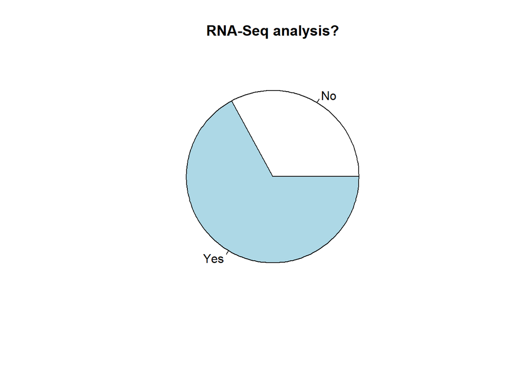

```r
fraqRNAseq = table(data_sample$RNA_SEQ_ANALYSIS)

pie(fraqRNAseq, main = "RNA-Seq analysis?")
```

- **table(data_sample$RNA_SEQ_ANALYSIS)** -> Conta a frequência de cada categoria presente na coluna “RNA_SEQ_ANALYSIS”;
- **pie(table(data_sample$RNA_SEQ_ANALYSIS), main = “RNA-Seq analysis?”)** -> Cria um pie chart que mostra a distribuição dos valores da coluna;

```r
sample_data_rna = data_sample[data_sample$RNA_SEQ_ANALYSIS == 'Yes',]

dim(sample_data_rna)
```

```
## [1] 451  74
```

```r
sum(row.names(sample_data_rna) %in% colnames(RNA_cpm))
```

```
## [1] 451
```

- **sample_data_rna = data_sample[data_sample$RNA_SEQ_ANALYSIS == ‘Yes’,]** -> Filtra o dataframe para icluir apenas os valores que correspondem a “YES”;
- **sum(row.names(sample_data_rna) %in% colnames(RNA_cpm))** -> Calcula o número de linhas em “sample_data_rna” que estão presentes nas colunas do “RNA_cpm”.

O código em cima serviu como filtro para perceber que dados de RNA-seq utilizar nas análises posteriores, garantindo que coincidem com os dados do dataset “RNA_cpm”.

#### 2.2.2.2 data_patient

Começámos por verificar alguns aspetos relativos ao dataset:

```r
class(data_patient)
```

```
## [1] "data.frame"
```

```r
dim(data_patient)
```

```
## [1] 562  22
```

```r
unlist(lapply(data_patient,class))
```

```
##                              PATIENT_ID                                     SEX
##                             "character"                             "character"
##                               ETHNICITY                        AGE_AT_DIAGNOSIS
##                             "character"                               "numeric"
##         MDSMPN_DIAGNOSIS_AT_ACQUISITION NON_AML_MDSMPN_DIAGNOSIS_AT_ACQUISITION
##                             "character"                             "character"
##                            PRIOR_CANCER                            CHEMOTHERAPY
##                             "character"                             "character"
##            PRIORRADIATIONFOROTHERCANCER                               PRIOR_MDS
##                             "character"                             "character"
##                MDS_TWO_MONTHS_PRIOR_AML                            PRIOR_MDSMPN
##                             "character"                             "character"
##             MDSMPN_TWO_MONTHS_PRIOR_AML                               PRIOR_MPN
##                             "character"                             "character"
##                MPN_TWO_MONTHS_PRIOR_AML                  DIAGNOSIS_AT_INCLUSION
##                             "character"                             "character"
##                               DIAGNOSIS                          TREATMENT_TYPE
##                             "character"                             "character"
##                               OS_STATUS                               OS_MONTHS
##                             "character"                               "numeric"
##                   CAUSE_OF_DEATH_SOURCE                                  CENTER
##                             "character"                               "integer"
```

```r
str(data_patient)
```

```
## 'data.frame':    562 obs. of  22 variables:
##  $ PATIENT_ID                             : chr  "aml_ohsu_2018_17" "aml_ohsu_2018_29" "aml_ohsu_2018_45" "aml_ohsu_2018_50" ...
##  $ SEX                                    : chr  "Female" "Male" "Female" "Male" ...
##  $ ETHNICITY                              : chr  "White" "White" "White" "White" ...
##  $ AGE_AT_DIAGNOSIS                       : num  27 34 70 11 74 73 69 59 66 60 ...
##  $ MDSMPN_DIAGNOSIS_AT_ACQUISITION        : chr  "False" "False" "False" "False" ...
##  $ NON_AML_MDSMPN_DIAGNOSIS_AT_ACQUISITION: chr  "False" "False" "False" "False" ...
##  $ PRIOR_CANCER                           : chr  "Juvenile pilocytic astrocytoma" "" "" "" ...
##  $ CHEMOTHERAPY                           : chr  "Yes" "Yes" "Yes" "Yes" ...
##  $ PRIORRADIATIONFOROTHERCANCER           : chr  "No" "No" "No" "No" ...
##  $ PRIOR_MDS                              : chr  "No" "No" "No" "No" ...
##  $ MDS_TWO_MONTHS_PRIOR_AML               : chr  "No" "No" "No" "No" ...
##  $ PRIOR_MDSMPN                           : chr  "No" "No" "No" "No" ...
##  $ MDSMPN_TWO_MONTHS_PRIOR_AML            : chr  "No" "No" "No" "No" ...
##  $ PRIOR_MPN                              : chr  "No" "No" "No" "No" ...
##  $ MPN_TWO_MONTHS_PRIOR_AML               : chr  "No" "No" "No" "No" ...
##  $ DIAGNOSIS_AT_INCLUSION                 : chr  "Acute Myeloid Leukaemia (AML) and Related Precursor Neoplasms" "Acute Myeloid Leukaemia (AML) and Related Precursor Neoplasms" "Acute Myeloid Leukaemia (AML) and Related Precursor Neoplasms" "Acute Myeloid Leukaemia (AML) and Related Precursor Neo…
##  $ DIAGNOSIS                              : chr  "Acute Myeloid Leukaemia (AML) and Related Precursor Neoplasms" "Acute Myeloid Leukaemia (AML) and Related Precursor Neoplasms" "Acute Myeloid Leukaemia (AML) and Related Precursor Neoplasms" "Acute Myeloid Leukaemia (AML) and Related Precursor Neo…
##  $ TREATMENT_TYPE                         : chr  "Standard Chemotherapy|Bone Marrow Transplant|Targeted Therapy - Kinase Inhibitor(s)" "Standard Chemotherapy" "Standard Chemotherapy|Intrathecal" "DLI|Standard Chemotherapy|Bone Marrow Transplant|Targeted Therapy - Kinase Inhibitor(s)|Intrathecal" …
##  $ OS_STATUS                              : chr  "1:DECEASED" "1:DECEASED" "1:DECEASED" "1:DECEASED" ...
##  $ OS_MONTHS                              : num  48.1 19.6 16.8 54.4 41.6 ...
##  $ CAUSE_OF_DEATH_SOURCE                  : chr  "Dead-Disease" "Dead-Unknown" "Dead-Other" "Dead-Disease" ...
##  $ CENTER                                 : int  1 1 1 1 1 1 1 1 1 1 ...
```

```r
head(row.names(data_patient))
```

```
## [1] "1" "2" "3" "4" "5" "6"
```

```r
row.names(data_patient) <- data_patient$PATIENT_ID

head(row.names(data_patient))
```

```
## [1] "aml_ohsu_2018_17"  "aml_ohsu_2018_29"  "aml_ohsu_2018_45"
## [4] "aml_ohsu_2018_50"  "aml_ohsu_2018_127" "aml_ohsu_2018_163"
```

```r
data_patient <- data_patient[,-1]
```

O dataset corresponde a um dataframe com 562 amostras e 22 variáveis. As colunas possuem três tipos de estrutura de dados (“character”, “integer” e “numeric”)

Depois vamos ver se exitem NAs.

```r
sum(is.na(data_patient))
```

```
## [1] 71
```

- **sum(is.na(data_patient))** -> Calcula a soma de todos os NAs.

Existem 71 NAs, mas em metadados é normal e por isso iremos mantê-los por agora.

Por fim, realizamos a criação de um subset, tal como fizemos com os metadados anteriores, para garantir um dataframe com dados de pacientes presentes em “sample_data_rna”, garantindo assim uma análise aos pacientes para os quais possuimos dados relevantes.

```r
patient_data_rna <- data_patient %>% filter(row.names(data_patient) %in% sample_data_rna$PATIENT_ID)
```

- **patient_data_rna = data_patient %>% filter(data_patient$PATIENT_ID %in% sample_data_rna$PATIENT_ID)** -> Cria um novo dataframe (“patient_data_rna”) filtrando o dataframe (“data_patient”) com base nos IDs dos pacientes presentes no dataframe.

### 2.2.3 data_mutations

Começámos por verificar alguns aspetos relativos ao dataset:

```r
class(data_mutations)
```

```
## [1] "data.frame"
```

```r
dim(data_mutations)
```

```
## [1] 9910   64
```

```r
unlist(lapply(data_mutations,class))
```

```
##                   Hugo_Symbol                Entrez_Gene_Id
##                   "character"                     "integer"
##                        Center                    NCBI_Build
##                   "character"                   "character"
##                    Chromosome                Start_Position
##                   "character"                     "integer"
##                  End_Position                        Strand
##                     "integer"                   "character"
##                   Consequence        Variant_Classification
##                   "character"                   "character"
##                  Variant_Type              Reference_Allele
##                   "character"                   "character"
##             Tumor_Seq_Allele1             Tumor_Seq_Allele2
##                   "character"                   "character"
##                      dbSNP_RS              dbSNP_Val_Status
##                     "logical"                     "logical"
##          Tumor_Sample_Barcode   Matched_Norm_Sample_Barcode
##                   "character"                     "logical"
##        Match_Norm_Seq_Allele1        Match_Norm_Seq_Allele2
##                     "logical"                     "logical"
##      Tumor_Validation_Allele1      Tumor_Validation_Allele2
##                     "logical"                     "logical"
## Match_Norm_Validation_Allele1 Match_Norm_Validation_Allele2
##                     "logical"                     "logical"
##           Verification_Status             Validation_Status
##                     "logical"                   "character"
##               Mutation_Status              Sequencing_Phase
##                   "character"                     "logical"
##               Sequence_Source             Validation_Method
##                     "logical"                     "logical"
##                         Score                      BAM_File
##                     "logical"                     "logical"
##                     Sequencer                   t_ref_count
##                   "character"                     "integer"
##                   t_alt_count                   n_ref_count
##                     "integer"                     "integer"
##                   n_alt_count                         HGVSc
##                     "integer"                   "character"
##                         HGVSp                   HGVSp_Short
##                   "character"                   "character"
```

[output cut: 9 more lines]

```
##                   "character"                   "character"
##            chosen_consequence                        codons
##                   "character"                   "character"
##                  ensembl_gene                       exac_af
##                   "character"                     "numeric"
##            existing_variation                          exon
##                   "character"                   "character"
##                        impact                         n_vaf
##                   "character"                     "numeric"
##                      polyphen                    rna_status
##                   "character"                   "character"
##               short_aa_change                          sift
##                   "character"                   "character"
##                         t_vaf                    tumor_only
##                     "numeric"                     "integer"
```

```r
head(row.names(data_mutations))
```

```
## [1] "1" "2" "3" "4" "5" "6"
```

```r
row.names(data_mutations) = make.unique(data_mutations$Hugo_Symbol)

head(row.names(data_mutations))
```

```
## [1] "C1orf170"   "C1orf170.1" "C1orf170.2" "C1orf170.3" "AGRN"
## [6] "AGRN.1"
```

```r
sum(is.na(data_mutations))
```

```
## [1] 155469
```

- **unlist(lapply(data_mutations,class))** -> Aplica a função class a cada coluna do dataframe;
- **row.names(data_mutations) = make.unique(data_mutations$Hugo_Symbol)** -> Associa os dados presentes na coluna “Hugo_Symbol” com os nomes das linhas nos dataframes, e para evitar duplicados, adiciona um sufixo.

É possível ver que temos um dataframe com 9910 linhas e 64 colunas. No dataframe existem também um número bastante elevados de NAs, 155469.

De seguida, vamos verificar a estrutura interna dos dados de cada coluna:

```r
str(data_mutations)
```

```
## 'data.frame':    9910 obs. of  64 variables:
##  $ Hugo_Symbol                  : chr  "C1orf170" "C1orf170" "C1orf170" "C1orf170" ...
##  $ Entrez_Gene_Id               : int  84808 84808 84808 84808 375790 375790 118424 54973 54973 83858 ...
##  $ Center                       : chr  "ohsu.edu" "ohsu.edu" "ohsu.edu" "ohsu.edu" ...
##  $ NCBI_Build                   : chr  "GRCh37" "GRCh37" "GRCh37" "GRCh37" ...
##  $ Chromosome                   : chr  "1" "1" "1" "1" ...
##  $ Start_Position               : int  914477 914477 914941 914941 982281 982281 1192625 1254771 1254771 1417649 ...
##  $ End_Position                 : int  914477 914477 914941 914941 982281 982281 1192625 1254771 1254771 1417649 ...
##  $ Strand                       : chr  "+" "+" "+" "+" ...
##  $ Consequence                  : chr  "missense_variant" "missense_variant" "missense_variant" "missense_variant" ...
##  $ Variant_Classification       : chr  "Missense_Mutation" "Missense_Mutation" "Missense_Mutation" "Missense_Mutation" ...
##  $ Variant_Type                 : chr  "SNP" "SNP" "SNP" "SNP" ...
##  $ Reference_Allele             : chr  "C" "C" "G" "G" ...
##  $ Tumor_Seq_Allele1            : chr  "C" "C" "G" "G" ...
##  $ Tumor_Seq_Allele2            : chr  "T" "T" "A" "A" ...
```

[output cut: 50 more lines]

```r
colunas_fator <- c(1, 9, 10, 11, 12, 13, 14, 15, 16, 18, 19, 20, 21, 22, 23, 24, 25, 26, 27, 28,29,30,31,32, 33, 45, 47, 48, 51, 57, 60, 64)

colunas_numericas <- c(34,35,36,37,43, 54, 58, 63)

colunas_char <- c(2,6,7)

data_mutations[, colunas_fator]<- lapply(data_mutations[, colunas_fator], as.factor)

data_mutations[, colunas_numericas]<- lapply(data_mutations[, colunas_numericas], as.numeric)

data_mutations[, colunas_char]<- lapply(data_mutations[, colunas_char], as.character)
```

- **colunas_fator <- c(1, 9, 10, 11, 12, 13, 14, 15, 16, 18, 19, 20, 21, 22, 23, 24, 25, 26, 27, 28,29,30,31,32, 33, 45, 47, 48, 51, 57, 60, 64)** -> Cria um vetor com colunas para as transformar em fatores;
- **colunas_numericas <- c(34,35,36,37,43, 54, 58, 63)** -> Cria um vetor com colunas para as transformar em valores numéricos;
- **colunas_char <- c(2,6,7)** -> Cria um vetor com colunas para as transformar em caracteres;
- **data_mutations[, colunas_fator]<- lapply(data_mutations[, colunas_fator], as.factor)** -> Transforma as colunas selecionadas anteriormente em fatores;
- **data_mutations[, colunas_numericas]<- lapply(data_mutations[, colunas_numericas], as.numeric)** -> Transforma as colunas selecionadas anteriormente em numéricos;
- **data_mutations[, colunas_char]<- lapply(data_mutations[, colunas_char], as.character)** ->Transforma as colunas selecionadas anteriormente em caracteres;

Ao analisar a estrutura de dados de cada coluna, percebemos que era necessário transformar alguns dos dados para facilitar a sua manipulação:

- os valores das colunas presentes no vetor associado a “colunas_fator” foram transformadas em fatores;
- os valores das colunas presentes no vetor associado a “colunas_numericas” foram transformados em valores numéricos;
- os valores das colunas presentes no vetor associado a “colunas_char” foram transformados em caracteres.

Por fim, procedemos à criação de um subset que contém apenas as linhas de “data_mutations” correspondentes às mutações que estão presentes nos dados de “RNA_cpm” para restringir a análise apenas às mutações para as quais temos dados de expressão gênica.

```r
mutations_subset = data_mutations %>% filter(data_mutations$Hugo_Symbol %in% RNA_cpm$Hugo_Symbol)
head(mutations_subset)
```

```
##          Hugo_Symbol Entrez_Gene_Id   Center NCBI_Build Chromosome
## AGRN            AGRN         375790 ohsu.edu     GRCh37          1
## AGRN.1          AGRN         375790 ohsu.edu     GRCh37          1
## UBE2J2        UBE2J2         118424 ohsu.edu     GRCh37          1
## CPSF3L        CPSF3L          54973 ohsu.edu     GRCh37          1
## CPSF3L.1      CPSF3L          54973 ohsu.edu     GRCh37          1
## ATAD3B        ATAD3B          83858 ohsu.edu     GRCh37          1
##          Start_Position End_Position Strand      Consequence
## AGRN             982281       982281      + missense_variant
## AGRN.1           982281       982281      + missense_variant
## UBE2J2          1192625      1192625      + missense_variant
## CPSF3L          1254771      1254771      + missense_variant
## CPSF3L.1        1254771      1254771      + missense_variant
## ATAD3B          1417649      1417649      + missense_variant
##          Variant_Classification Variant_Type Reference_Allele Tumor_Seq_Allele1
## AGRN          Missense_Mutation          SNP                G                 G
## AGRN.1        Missense_Mutation          SNP                G                 G
## UBE2J2        Missense_Mutation          SNP                T                 T
## CPSF3L        Missense_Mutation          SNP                C                 C
## CPSF3L.1      Missense_Mutation          SNP                C                 C
## ATAD3B        Missense_Mutation          SNP                T                 T
##          Tumor_Seq_Allele2 dbSNP_RS dbSNP_Val_Status   Tumor_Sample_Barcode
## AGRN                     T     <NA>             <NA> aml_ohsu_2018_14-00676
## AGRN.1                   T     <NA>             <NA> aml_ohsu_2018_14-00676
## UBE2J2                   G     <NA>             <NA> aml_ohsu_2018_13-00515
## CPSF3L                   T     <NA>             <NA> aml_ohsu_2018_15-00805
## CPSF3L.1                 T     <NA>             <NA> aml_ohsu_2018_15-00805
## ATAD3B                   G     <NA>             <NA> aml_ohsu_2018_14-00244
##          Matched_Norm_Sample_Barcode Match_Norm_Seq_Allele1
## AGRN                            <NA>                   <NA>
## AGRN.1                          <NA>                   <NA>
## UBE2J2                          <NA>                   <NA>
## CPSF3L                          <NA>                   <NA>
## CPSF3L.1                        <NA>                   <NA>
## ATAD3B                          <NA>                   <NA>
##          Match_Norm_Seq_Allele2 Tumor_Validation_Allele1
## AGRN                       <NA>                     <NA>
## AGRN.1                     <NA>                     <NA>
## UBE2J2                     <NA>                     <NA>
## CPSF3L                     <NA>                     <NA>
```

[output cut: 57 more lines]

```
## ATAD3B     missense_variant Tcc/Gcc ENSG00000160072 0.00567        rs140940347
##           exon   impact      n_vaf                 polyphen rna_status
## AGRN     19/36 MODERATE 0.00000000 probably_damaging(0.972)  not_found
## AGRN.1   19/36 MODERATE 0.00000000 probably_damaging(0.972)  not_found
## UBE2J2     5/8 MODERATE 0.04545454            benign(0.168)      found
## CPSF3L    6/19 MODERATE 0.00000000 probably_damaging(0.957)   not_done
## CPSF3L.1  6/19 MODERATE 0.00000000 probably_damaging(0.957)   not_done
## ATAD3B    6/16 MODERATE 0.00000000            benign(0.001)   not_done
##          short_aa_change              sift      t_vaf tumor_only
## AGRN            p.G1111V    deleterious(0) 0.09352518          0
## AGRN.1          p.G1111V    deleterious(0) 0.10156250          0
## UBE2J2            p.M96L deleterious(0.05) 0.08620690          0
## CPSF3L           p.V118I deleterious(0.01) 0.13793103          0
## CPSF3L.1         p.V118I deleterious(0.01) 0.13953488          0
## ATAD3B           p.S216A      tolerated(1) 0.22222222          0
```

# 3 **Sumarização dos dados**

## 3.1 *patient_data_rna*

Primeiro vamos criar um subset apenas com as colunas mais interessantes de serem avaliadas, uma vez que este dataset apresenta 21 variáveis. Vamos também determinar os tipos de variáveis.

```r
colunas_relevantes = c("SEX", "ETHNICITY", "AGE_AT_DIAGNOSIS", "PRIOR_CANCER", "TREATMENT_TYPE", "OS_STATUS", "OS_MONTHS", "CAUSE_OF_DEATH_SOURCE", "DIAGNOSIS")
relev_data_patient <- patient_data_rna[,colunas_relevantes]

# Determinar algumas variáveis como fatores:
fatores = c("SEX", "ETHNICITY", "OS_STATUS", "CAUSE_OF_DEATH_SOURCE", "DIAGNOSIS")
relev_data_patient[, fatores] <- lapply(relev_data_patient[, fatores], as.factor)
```

```r
print(dfSummary(relev_data_patient, style = 'grid', graph.magnif = 1, valid.col = FALSE,
                max.distinct.values = 5, col.widths = c(100, 200, 200, 350, 500, 250),
                dfSummary.silent  = TRUE, headings = FALSE, justify = 'l')
      , method = 'render', max.tbl.height = 500)
```

| **No** | **Variable** | **Stats / Values** | **Freqs (% of Valid)** | **Graph** | **Missing** |
| --- | --- | --- | --- | --- | --- |
| 1 | SEX [factor] | 1. Female 2. Male | 178 ( 43.3% ) 233 ( 56.7% ) |  | 0 (0.0%) |
| 2 | ETHNICITY [factor] | 1. AdmixedAsian 2. AdmixedBlack 3. AdmixedWhite 4. Asian 5. Black [ 2 others ] | 1 ( 0.2% ) 2 ( 0.5% ) 1 ( 0.2% ) 13 ( 3.2% ) 14 ( 3.4% ) 380 ( 92.5% ) |  | 0 (0.0%) |
| 3 | AGE_AT_DIAGNOSIS [numeric] | Mean (sd) : 57 (18.1) min ≤ med ≤ max: 2 ≤ 61 ≤ 87 IQR (CV) : 25 (0.3) | 78 distinct values |  | 3 (0.7%) |
| 4 | PRIOR_CANCER [character] | 1. (Empty string) 2. Not specified 3. Breast Cancer 4. Lung Cancer 5. Non-Hodgkins Lymphoma [ 17 others ] | 361 ( 87.8% ) 11 ( 2.7% ) 9 ( 2.2% ) 4 ( 1.0% ) 4 ( 1.0% ) 22 ( 5.4% ) |  | 0 (0.0%) |
| 5 | TREATMENT_TYPE [character] | 1. Standard Chemotherapy 2. Standard Chemotherapy\|Bon 3. (Empty string) 4. Standard Chemotherapy\|Tar 5. Standard Chemotherapy\|Tar [ 24 others ] | 194 ( 47.2% ) 80 ( 19.5% ) 20 ( 4.9% ) 19 ( 4.6% ) 19 ( 4.6% ) 79 ( 19.2% ) |  | 0 (0.0%) |
| 6 | OS_STATUS [factor] | 1. (Empty string) 2. 0:LIVING 3. 1:DECEASED | 43 ( 10.5% ) 156 ( 38.0% ) 212 ( 51.6% ) |  | 0 (0.0%) |
| 7 | OS_MONTHS [numeric] | Mean (sd) : 13.8 (16) min ≤ med ≤ max: 0 ≤ 9.9 ≤ 174.5 IQR (CV) : 11.8 (1.2) | 289 distinct values |  | 46 (11.2%) |
| 8 | CAUSE_OF_DEATH_SOURCE [factor] | 1. (Empty string) 2. Alive 3. Dead-Disease 4. Dead-Other 5. Dead-Treatment 6. Dead-Unknown | 43 ( 10.5% ) 156 ( 38.0% ) 137 ( 33.3% ) 13 ( 3.2% ) 13 ( 3.2% ) 49 ( 11.9% ) |  | 0 (0.0%) |
| 9 | DIAGNOSIS [factor] | 1. Acute Leukaemias of Ambig 2. Acute Myeloid Leukaemia ( 3. Myelodysplastic Syndromes 4. Myeloproliferative Neopla | 2 ( 0.5% ) 400 ( 97.3% ) 6 ( 1.5% ) 3 ( 0.7% ) |  | 0 (0.0%) |

Generated by summarytools 1.0.1 ([R](https://www.r-project.org/) version 4.3.1)  
2024-04-10

## 3.2 *sample_data_rna*

Seguindo a mesma lógica, selecionamos as colunas mais relevantes:

```r
colunas_relevantes = c("PATIENT_ID", "GROUP", "SAMPLE_SITE", "PLATFORM", "AGE_AT_PROCUREMENT", "ELN_2017")

relev_data_sample <- sample_data_rna[,colunas_relevantes]

fatores <- c("GROUP", "SAMPLE_SITE", "PLATFORM", "ELN_2017")
relev_data_sample[, fatores] <- lapply(relev_data_sample[, fatores], as.factor)
relev_data_sample[, 5] <- as.numeric(relev_data_sample[, 5])
```

```r
print(dfSummary(relev_data_sample, style = 'grid', graph.magnif = 1, valid.col = FALSE,
                max.distinct.values = 5, col.widths = c(100, 200, 200, 350, 500, 250),
                dfSummary.silent  = TRUE, headings = FALSE, justify = 'l')
      , method = 'render', max.tbl.height = 500)
```

| **No** | **Variable** | **Stats / Values** | **Freqs (% of Valid)** | **Graph** | **Missing** |
| --- | --- | --- | --- | --- | --- |
| 1 | PATIENT_ID [character] | 1. aml_ohsu_2018_1973 2. aml_ohsu_2018_2119 3. aml_ohsu_2018_2337 4. aml_ohsu_2018_2694 5. aml_ohsu_2018_4197 [ 406 others ] | 3 ( 0.7% ) 3 ( 0.7% ) 3 ( 0.7% ) 3 ( 0.7% ) 3 ( 0.7% ) 436 ( 96.7% ) |  | 0 (0.0%) |
| 2 | GROUP [factor] | 1. Initial Acute Leukemia Di 2. Initial Acute Leukemia Di 3. Initial Acute Leukemia Di 4. Post-Chemotherapy 5. Post-Chemotherapy\|Initial [ 21 others ] | 281 ( 62.3% ) 4 ( 0.9% ) 1 ( 0.2% ) 20 ( 4.4% ) 3 ( 0.7% ) 142 ( 31.5% ) |  | 0 (0.0%) |
| 3 | SAMPLE_SITE [factor] | 1. Bone Marrow Aspirate 2. Leukapheresis 3. Peripheral Blood | 239 ( 53.0% ) 9 ( 2.0% ) 203 ( 45.0% ) |  | 0 (0.0%) |
| 4 | PLATFORM [factor] | 1. RNA-seq 2. WES + RNA-seq | 46 ( 10.2% ) 405 ( 89.8% ) |  | 0 (0.0%) |
| 5 | AGE_AT_PROCUREMENT [numeric] | Mean (sd) : 57.2 (18.1) min ≤ med ≤ max: 2 ≤ 61 ≤ 87 IQR (CV) : 24 (0.3) | 75 distinct values |  | 1 (0.2%) |
| 6 | ELN_2017 [factor] | 1. Adverse 2. Favorable 3. Favorable or Intermediate 4. Intermediate 5. Intermediate or Adverse 6. Unknown | 162 ( 35.9% ) 117 ( 25.9% ) 14 ( 3.1% ) 150 ( 33.3% ) 7 ( 1.6% ) 1 ( 0.2% ) |  | 0 (0.0%) |

Generated by summarytools 1.0.1 ([R](https://www.r-project.org/) version 4.3.1)  
2024-04-10

## 3.3 *mutations_subset*

```r
colunas_relevantes = c("Chromosome", "Start_Position", "End_Position", "Strand", "Variant_Classification", "Variant_Type", "Tumor_Seq_Allele1", "Tumor_Seq_Allele2", "Validation_Status", "Mutation_Status", "impact", "n_vaf")

relev_data_mutations = mutations_subset[, colunas_relevantes]
```

```r
print(dfSummary(relev_data_mutations, style = 'grid', graph.magnif = 1, valid.col = FALSE,
                max.distinct.values = 5, col.widths = c(100, 200, 200, 350, 500, 250),
                dfSummary.silent  = TRUE, headings = FALSE, justify = 'l')
      , method = 'render', max.tbl.height = 500)
```

| **No** | **Variable** | **Stats / Values** | **Freqs (% of Valid)** | **Graph** | **Missing** |
| --- | --- | --- | --- | --- | --- |
| 1 | Chromosome [character] | 1. 2 2. 1 3. 17 4. 11 5. 19 [ 19 others ] | 743 ( 9.1% ) 694 ( 8.5% ) 546 ( 6.7% ) 459 ( 5.6% ) 454 ( 5.6% ) 5249 ( 64.4% ) |  | 0 (0.0%) |
| 2 | Start_Position [character] | 1. 170837543 2. 90631934 3. 74732959 4. 25457242 5. 209113113 [ 3891 others ] | 109 ( 1.3% ) 107 ( 1.3% ) 106 ( 1.3% ) 97 ( 1.2% ) 69 ( 0.8% ) 7657 ( 94.0% ) |  | 0 (0.0%) |
| 3 | End_Position [character] | 1. 170837544 2. 74732959 3. 90631934 4. 25457242 5. 209113113 [ 3891 others ] | 109 ( 1.3% ) 109 ( 1.3% ) 107 ( 1.3% ) 97 ( 1.2% ) 69 ( 0.8% ) 7654 ( 94.0% ) |  | 0 (0.0%) |
| 4 | Strand [character] | 1. + | 8145 ( 100.0% ) |  | 0 (0.0%) |
| 5 | Variant_Classification [factor] | 1. Frame_Shift_Del 2. Frame_Shift_Ins 3. In_Frame_Del 4. In_Frame_Ins 5. Intron [ 5 others ] | 309 ( 3.8% ) 388 ( 4.8% ) 228 ( 2.8% ) 177 ( 2.2% ) 1 ( 0.0% ) 7042 ( 86.5% ) |  | 0 (0.0%) |
| 6 | Variant_Type [factor] | 1. DEL 2. INS 3. SNP | 566 ( 6.9% ) 580 ( 7.1% ) 6999 ( 85.9% ) |  | 0 (0.0%) |
| 7 | Tumor_Seq_Allele1 [factor] | 1. - 2. A 3. AA 4. AAAG 5. AAC [ 141 others ] | 580 ( 7.1% ) 804 ( 9.9% ) 1 ( 0.0% ) 2 ( 0.0% ) 1 ( 0.0% ) 6757 ( 83.0% ) |  | 0 (0.0%) |
| 8 | Tumor_Seq_Allele2 [factor] | 1. - 2. A 3. AA 4. AAATTTTCTCTTGGAAACTCCCATT 5. AACCAAACTCTAAATTTTCTCTTGG [ 210 others ] | 566 ( 6.9% ) 2520 ( 30.9% ) 3 ( 0.0% ) 1 ( 0.0% ) 1 ( 0.0% ) 5054 ( 62.1% ) |  | 0 (0.0%) |
| 9 | Validation_Status [factor] | 1. not_covered 2. not_done 3. not_found 4. validated | 495 ( 6.1% ) 6604 ( 81.1% ) 85 ( 1.0% ) 961 ( 11.8% ) |  | 0 (0.0%) |
| 10 | Mutation_Status [factor] | 1. Somatic | 8145 ( 100.0% ) |  | 0 (0.0%) |
| 11 | impact [factor] | 1. HIGH 2. MODERATE 3. MODIFIER | 1577 ( 19.4% ) 6525 ( 80.1% ) 43 ( 0.5% ) |  | 0 (0.0%) |
| 12 | n_vaf [numeric] | Mean (sd) : 0 (0) min ≤ med ≤ max: 0 ≤ 0 ≤ 1 IQR (CV) : 0 (2.4) | 630 distinct values |  | 0 (0.0%) |

Generated by summarytools 1.0.1 ([R](https://www.r-project.org/) version 4.3.1)  
2024-04-10

# 4 **Análise exploratória**

## 4.1 *patient_data_rna*

Considerando variáveis relevantes:

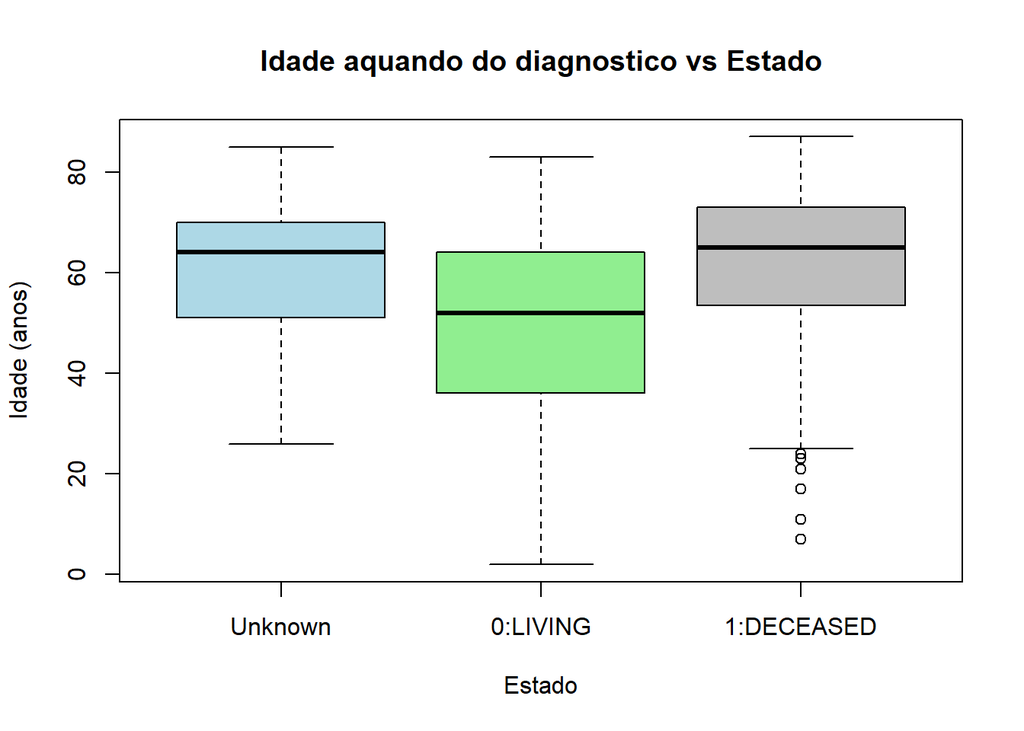

```r
boxplot(AGE_AT_DIAGNOSIS ~ OS_STATUS, data = relev_data_patient, main = "Idade aquando do diagnostico vs Estado", xlab = "Estado", ylab = "Idade (anos)", col = c("lightblue", "lightgreen", "grey"), names = c("Unknown", "0:LIVING", "1:DECEASED"))
```

O código em cima cria um boxplot que compara as distribuições das idades aquando do diagnóstico entre os diferentes estados de sobrevida. É possível observar que a idade com que foram diagnosticados não parece ter uma influência ou associação significativa com a sobrevivência do paciente, embora a idade aquando do diagnóstico seja menor nos pacientes que ainda estão vivos, o que pode ter a ver com o facto da rapidez de diagnóstico estar normalmente associada a uma maior taxa de sobrevivência.

De seguida, decidimos averiguar a distribuição das etnias:

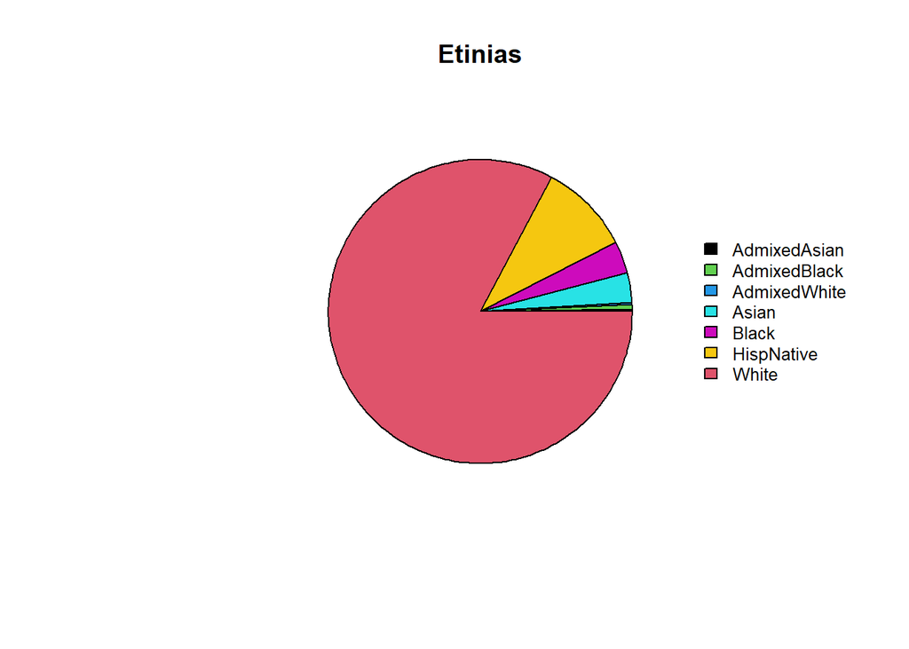

```r
valores = table(relev_data_patient$ETHNICITY)

nome = c("AdmixedAsian", "AdmixedBlack", "AdmixedWhite", "Asian", "Black", "HispNative", "White")


pie(valores, labels = rep("", length(valores)), col = c("black",3,4,5,6,7,2), main = "Etinias")

legend("right", legend = nome, bty = "n", cex = 0.8, fill = c("black",3,4,5,6,7,2))
```

Verificámos que as etnias mais representadas neste dataset são “White”, “Hispanic Native”, “Black” e “Asian” respetivamente.

De seguida, procedemos à comparação da idade de diagnóstico entre os géneros

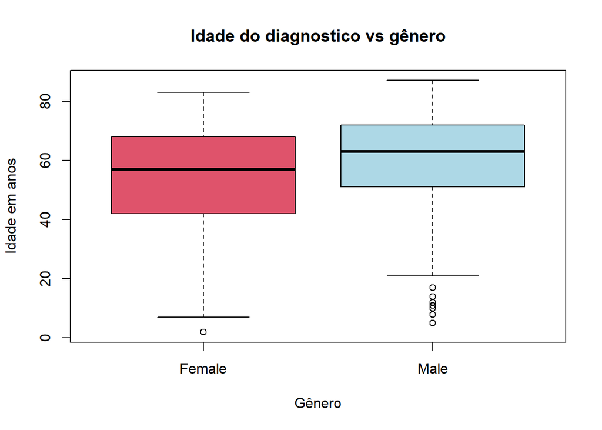

```r
boxplot(AGE_AT_DIAGNOSIS ~ SEX, data = relev_data_patient, main = "Idade do diagnostico vs gênero", xlab = "Gênero", ylab = "Idade em anos", col = c(2,'lightblue'))
```

No boxplot é possível observar que a idade dos pacientes masculinos, é ligeiramente mais elevada, possuindo limites, quartis e mediana com idades superiores comparativamente aos pacientes femininos. Verifica-se também uma maior presença de outliers nos dados dos pacientes masculinos comparativamente aos femininos.

Finalmente, fizemos uma análise sobre o diagnóstico mais recorrente que revelou ser ‘Acute Myeloid Leukaemia (AML) and Related Precursor Neoplasms’.

```r
d = table(relev_data_patient$DIAGNOSIS)

d = as.data.frame(d)

indice_maximo <- which.max(d$Freq)

nome_maximo <- d$Var1[indice_maximo]

nome_maximo
```

```
## [1] Acute Myeloid Leukaemia (AML) and Related Precursor Neoplasms
## 4 Levels: Acute Leukaemias of Ambiguous Lineage ...
```

## 4.2 *sample_data_rna*

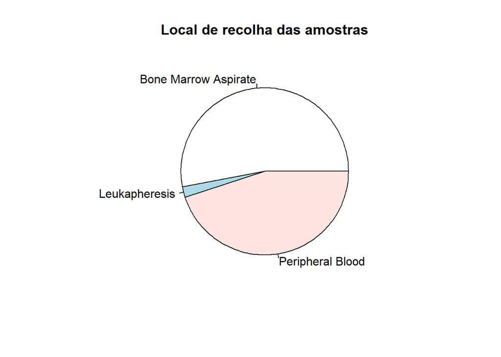

```r
pie(table(relev_data_sample$SAMPLE_SITE), main = "Local de recolha das amostras")
```

O gráfico demonstra como as amostras estão distribuídas pelos locais de recolha. Os locais de recolha de amostra mais frequentes entre os dados analisados são o “Aspirado de Medula Óssea” com pouco mais de 50% das amostras, o “Sangue Periférico” com uma distribuição pouco menor do que 50% das amostras, e a “Leucaferese” com opção menos utilizada.

Por último verificamos qual o nome do grupo de diagnóstico mais frequente nos dados

```r
x = table(relev_data_sample$GROUP)

x = as.data.frame(x)

indice_maximo <- which.max(x$Freq)

nome_maximo <- x$Var1[indice_maximo]

nome_maximo
```

```
## [1] Initial Acute Leukemia Diagnosis
## 26 Levels: Initial Acute Leukemia Diagnosis ...
```

## 4.3 *mutations_subset*

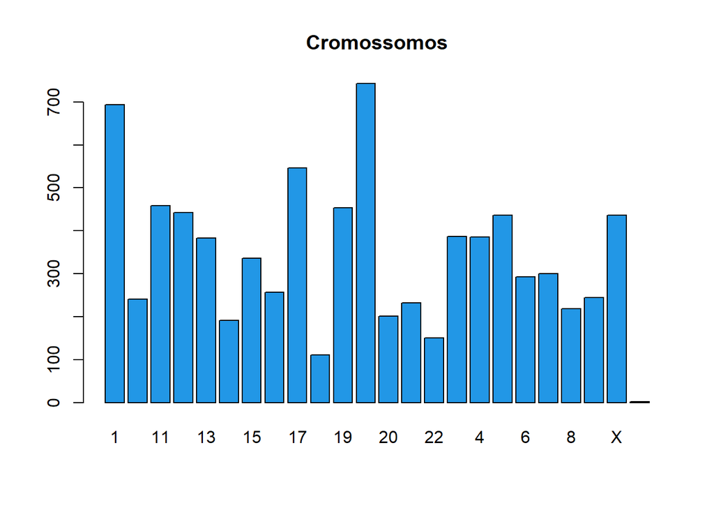

```r
barplot(table(relev_data_mutations$Chromosome), main = "Cromossomos", col = "4")
```

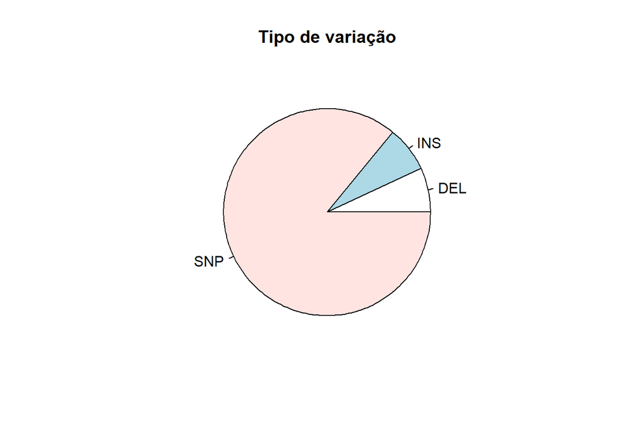

```r
pie(table(relev_data_mutations$Variant_Type), main = "Tipo de variação")
```

Com o código em cima, geramos um gráfico de barras que mostra a contagem de ocorrências de cada cromossoma, e um gráfico de pizza para perceber a distribuição dos tipos de variantes no dataframe.

É possível observar que a variante mais frequente no dataframe é a “SNP”, seguida da “INS” e da “DEL”.

Depois, verificamos qual a mutação mais comum no Alelo 1 entre as amostras analisadas

```r
mut = table(relev_data_mutations$Tumor_Seq_Allele1)

mut = as.data.frame(mut)

indice_maximo <- which.max(mut$Freq)

nome_maximo <- mut$Var1[indice_maximo]

nome_maximo
```

```
## [1] C
## 146 Levels: - A AA AAAG AAC AACCAAAATATGCAGGG AACTCCAT AAG AAGTAAGAG ... TTGAAGAGTT
```

A mutação mais comum referente ao Alelo 1, é a alteração por Citosinas. Este dado pode ser útil na identificação de uma doença ou de um potêncial alvo terapêutico.

Analisamos ainda qual a mutação mais comum no Alelo 2 entre as amostras analisadas:

```r
mut2 = table(relev_data_mutations$Tumor_Seq_Allele2)

mut2 = as.data.frame(mut2)

indice_maximo <- which.max(mut2$Freq)

nome_maximo <- mut2$Var1[indice_maximo]

nome_maximo # A mutação mais comum é a alteração por T
```

```
## [1] T
## 215 Levels: - A AA ... TTTTCTCTTGGAAACTCCCATTTGAGATCATATTCATATTCTCTGAAATCAACGTAGAAG
```

Já no Alelo 2, a mutação mais comum é a alteração por Timina.

# 5 **Análise Univariada**

## 5.1 *Análise com as variáveis do metadado dos pacientes*

As variáveis analisadas foram: Idade e sexo dos pacientes, teve como objectivo de determinar se os dois grupos de sexo (“Male” e “Female”) deferiam quanto as idades. Para fazer esta análise, foi avaliado se os dois diferentes grupos apresentam médias diferentes.

```r
table(relev_data_patient$SEX) # Confirmação de quantos grupos de sexos há.
```

```
##
## Female   Male
##    178    233
```

```r
# Testar a homogeneidade das variâncias
leveneTest(relev_data_patient$AGE_AT_DIAGNOSIS~relev_data_patient$SEX) # Não rejeitar a hipótese de que as variâncias dos grupos são iguais.
```

```
## Levene's Test for Homogeneity of Variance (center = median)
##        Df F value Pr(>F)
## group   1  1.2981 0.2552
##       406
```

```r
# Testar a normalidade dos diferentes grupos
teste_normalidade_masculino=shapiro.test(relev_data_patient$AGE_AT_DIAGNOSIS[relev_data_patient$SEX == "Male"])
teste_normalidade_feminino=shapiro.test(relev_data_patient$AGE_AT_DIAGNOSIS[relev_data_patient$SEX == "Female"])
print(teste_normalidade_masculino) # Não normal
```

```
##
##  Shapiro-Wilk normality test
##
## data:  relev_data_patient$AGE_AT_DIAGNOSIS[relev_data_patient$SEX == "Male"]
## W = 0.92143, p-value = 1.074e-09
```

```r
print(teste_normalidade_feminino) # Não normal
```

```
##
##  Shapiro-Wilk normality test
##
## data:  relev_data_patient$AGE_AT_DIAGNOSIS[relev_data_patient$SEX == "Female"]
## W = 0.96201, p-value = 9.338e-05
```

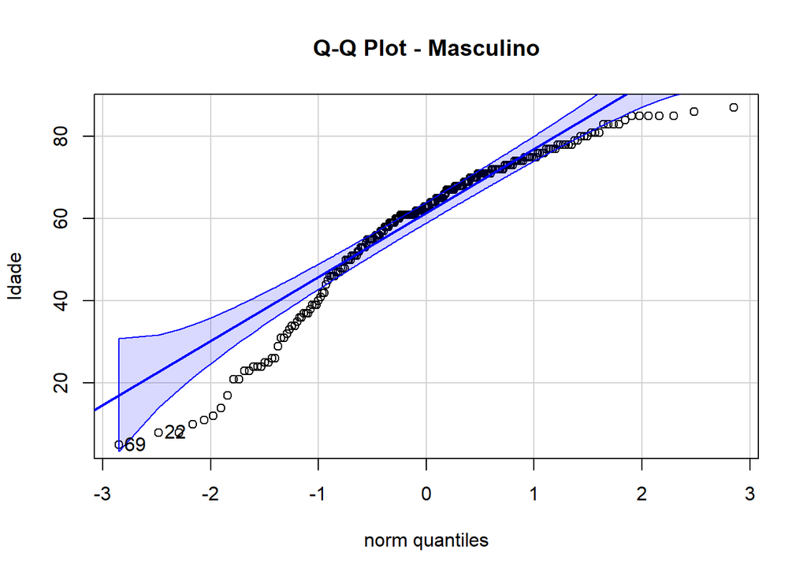

```
## [1] 69 22
```

```r
# Visualização da normalidade com qqPlot
qqPlot(relev_data_patient$AGE_AT_DIAGNOSIS[relev_data_patient$SEX == "Male"], main = "Q-Q Plot - Masculino", ylab = "Idade")
```

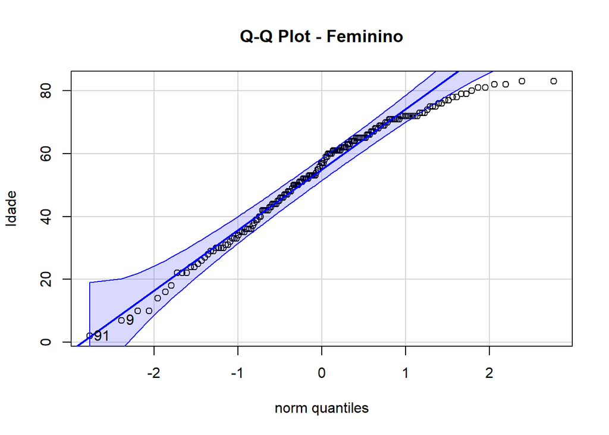

```
## [1] 91  9
```

```r
qqPlot(relev_data_patient$AGE_AT_DIAGNOSIS[relev_data_patient$SEX == "Female"], main = "Q-Q Plot - Feminino", ylab = "Idade")
```

```r
# Normalidade geral das idades
shapiro.test(relev_data_patient$AGE_AT_DIAGNOSIS) # Não normal
```

```
##
##  Shapiro-Wilk normality test
##
## data:  relev_data_patient$AGE_AT_DIAGNOSIS
## W = 0.94448, p-value = 3.148e-11
```

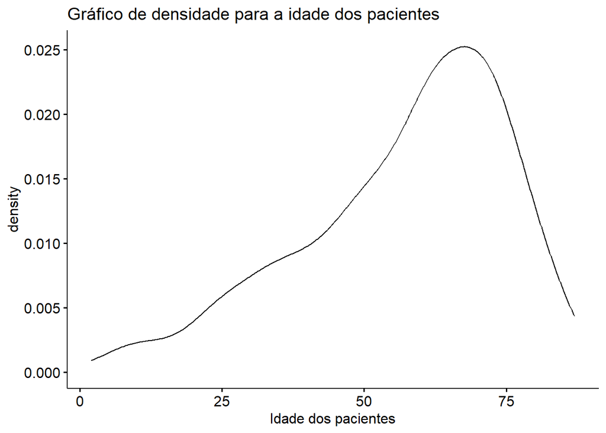

```r
# Retirada dos NAs:
idades_sem_na <- na.omit(relev_data_patient$AGE_AT_DIAGNOSIS)

# Criar gráfico de densidade sem valores ausentes
ggdensity(idades_sem_na,
          main = "Gráfico de densidade para a idade dos pacientes",
          xlab = "Idade dos pacientes")
```

Não pode rejeitar a hipótese nula, nesse caso que as variâncias são homogéneas, e com os gráficos qqPlot e as análises de normalidade, foi possível determinar que as distribuições não são normais, mas considerando um tamanho elevado das amostras, realizamos um t-test e analisar relação entre sexo e idade.

```r
# T-test
t.test(relev_data_patient$AGE_AT_DIAGNOSIS ~ relev_data_patient$SEX, na.rm = TRUE)
```

```
##
##  Welch Two Sample t-test
##
## data:  relev_data_patient$AGE_AT_DIAGNOSIS by relev_data_patient$SEX
## t = -3.1366, df = 380.14, p-value = 0.001842
## alternative hypothesis: true difference in means between group Female and group Male is not equal to 0
## 95 percent confidence interval:
##  -9.108764 -2.089184
## sample estimates:
## mean in group Female   mean in group Male
##             53.83146             59.43043
```

Com base na análise final, é possível concluir que as idades diferem para os grupos “Male” e “Female”. Isso implicaria que deve levar em consideração em análises de expressão com diferentes sexos que determinadas diferenças podem ser decorrentes da idade.

## 5.2 *Análise de varáveis no metadado de mutações*

- “n_vaf” (Frequência do Alelo Variante Normalizado),é a frequência do alelo variante, sendo uma variável numérica.
- Impact: variável que se refere ao efeito ou consequência que uma determinada mutação pode ter em um gene ou em uma função biológica específica. É uma variável nominal.

O objectivo dessa comparação é determinar se a frequência do alelo variante defere para diferentes impactos que as mutações apresentam, podendo ser útil para identificar mutações driver (aquelas que contribuem para a progressão e desnvolvimento do câncer).

```r
# Avaliar a variável "N_vaf" quanto a presença de NAs e distribuição
sum(is.na(relev_data_mutations$n_vaf))
```

```
## [1] 0
```

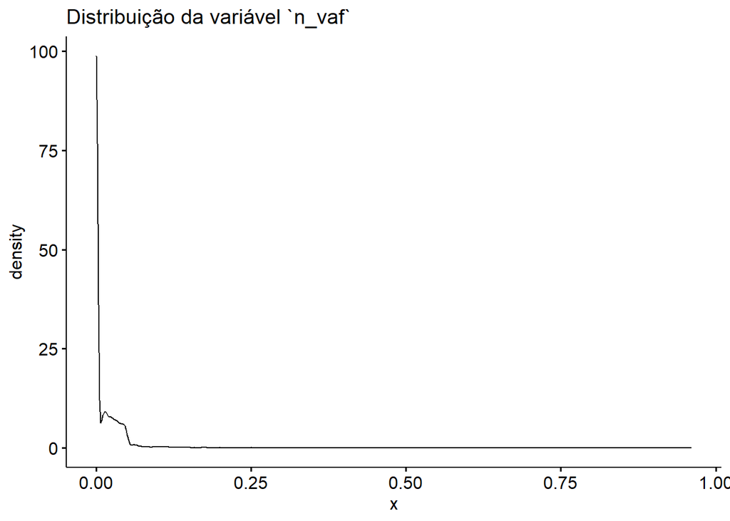

```r
ggdensity(relev_data_mutations$n_vaf, main = "Distribuição da variável `n_vaf`")
```

```r
# Avaliação das diferentes classes de impacto
table(relev_data_mutations$impact) # Há 3 classes: "High", "Moderate" e "Modifier"
```

```
##
##     HIGH MODERATE MODIFIER
##     1577     6525       43
```

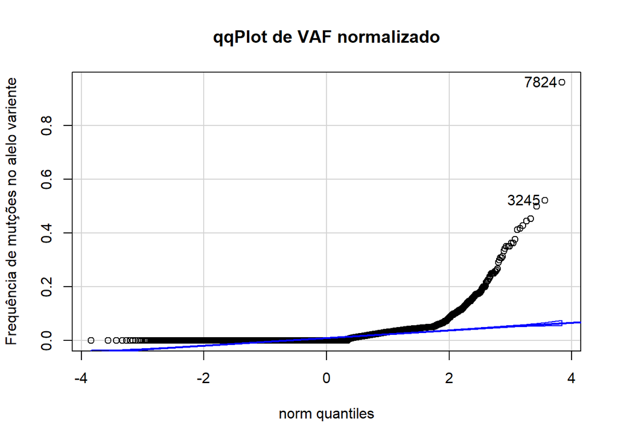

```
## [1] 7824 3245
```

```r
# Avaliar a normalidade de n_vaf
qqPlot(relev_data_mutations$n_vaf, ylab = "Frequência de mutções no alelo variente",  main = "qqPlot de VAF normalizado") # não é normal
```

```r
# Avaliar a homegneidade das variâncias
leveneTest(relev_data_mutations$n_vaf~relev_data_mutations$impact) # as variâncias entre diferentes grupos de impacto não são homogéneas.
```

```
## Levene's Test for Homogeneity of Variance (center = median)
##         Df F value    Pr(>F)
## group    2  7.2159 0.0007395 ***
##       8142
## ---
## Signif. codes:  0 '***' 0.001 '**' 0.01 '*' 0.05 '.' 0.1 ' ' 1
```

```r
# Teste se as medianas são ou não igaus para os diferentes grupos
res = kruskal.test(relev_data_mutations$n_vaf~relev_data_mutations$impact, data = relev_data_mutations)
res # Não são estatisticamente diferentes
```

```
##
##  Kruskal-Wallis rank sum test
##
## data:  relev_data_mutations$n_vaf by relev_data_mutations$impact
## Kruskal-Wallis chi-squared = 3.4471, df = 2, p-value = 0.1784
```

Com os resultados obtidos, não é possível rejeitar a hipótese nula que as medianas são iguais, nesse caso significa que não há variações significativas entre as frequências de mutações dos alelos variantes para diferentes grupos de impacto.

## 5.3 *Análise para variáveis do metadado das amostra*

- “AGE_AT_PROCUREMENT” - Idade dos pacientes na aquisição das amostras.
- “ELN_2017” - variável usada para classificar pacientes com leucemia mieloide aguda (LMA) em diferentes grupo de risco.

Esta análise tem como objectivo avaliar se a idade tem associação com diferentes grupos de risco.

```r
# Avaliação das variáveis
table(relev_data_sample$ELN_2017) # Há 6 grupos de clssificações de risco
```

```
##
##                   Adverse                 Favorable Favorable or Intermediate
##                       162                       117                        14
##              Intermediate   Intermediate or Adverse                   Unknown
##                       150                         7                         1
```

```r
summary(relev_data_sample$AGE_AT_PROCUREMENT) # Há um NA.
```

```
##    Min. 1st Qu.  Median    Mean 3rd Qu.    Max.    NA's
##    2.00   47.00   61.00   57.16   71.00   87.00       1
```

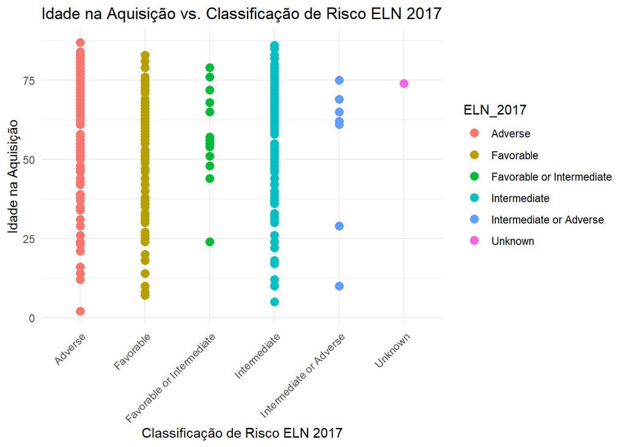

```r
# Criar o gráfico de dispersão
ggplot(relev_data_sample, aes(x = ELN_2017, y = AGE_AT_PROCUREMENT, color = ELN_2017)) +
  geom_point(size = 3) +
  labs(x = "Classificação de Risco ELN 2017", y = "Idade na Aquisição", title = "Idade na Aquisição vs. Classificação de Risco ELN 2017") +
  theme_minimal() +
  theme(axis.text.x = element_text(angle = 45, hjust = 1))
```

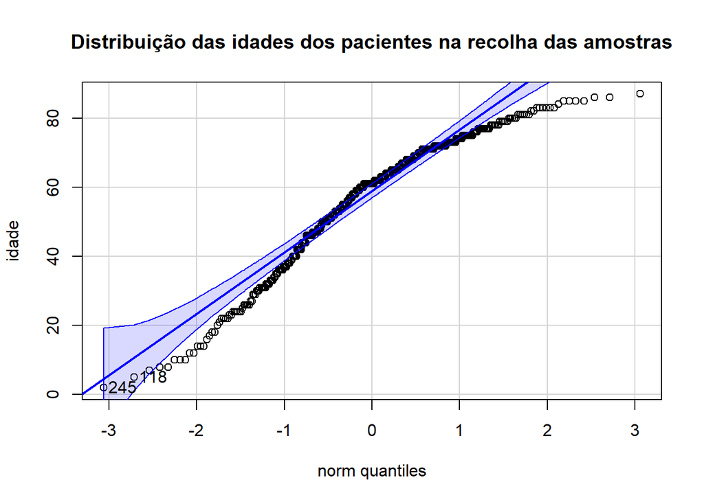

```
## [1] 245 118
```

```r
# Analisando a normalidade e homogeneidade das variâncias:

qqPlot(relev_data_sample$AGE_AT_PROCUREMENT, ylab = "idade", main = "Distribuição das idades dos pacientes na recolha das amostras")
```

```r
shapiro.test(relev_data_sample$AGE_AT_PROCUREMENT) # Não é normal
```

```
##
##  Shapiro-Wilk normality test
##
## data:  relev_data_sample$AGE_AT_PROCUREMENT
## W = 0.94194, p-value = 2.921e-12
```

```r
# Análise da variância
leveneTest(AGE_AT_PROCUREMENT ~ ELN_2017, data = relev_data_sample) # Homogénea
```

```
## Levene's Test for Homogeneity of Variance (center = median)
##        Df F value Pr(>F)
## group   5  0.6718  0.645
##       444
```

```r
# ANOVA
anova_result <- aov(AGE_AT_PROCUREMENT ~ ELN_2017, data = relev_data_sample)
summary(anova_result)
```

```
##              Df Sum Sq Mean Sq F value  Pr(>F)
## ELN_2017      5   5007  1001.4    3.14 0.00849 **
## Residuals   444 141585   318.9
## ---
## Signif. codes:  0 '***' 0.001 '**' 0.01 '*' 0.05 '.' 0.1 ' ' 1
## 1 observation deleted due to missingness
```

```r
## Análise por grupo:
tukey_result <- TukeyHSD(anova_result)
print(tukey_result)
```

```
##   Tukey multiple comparisons of means
##     95% family-wise confidence level
##
## Fit: aov(formula = AGE_AT_PROCUREMENT ~ ELN_2017, data = relev_data_sample)
##
## $ELN_2017
##                                                        diff         lwr
## Favorable-Adverse                                 -7.900285 -14.1014062
## Favorable or Intermediate-Adverse                 -1.671958 -15.9101015
## Intermediate-Adverse                              -1.418842  -7.2204462
## Intermediate or Adverse-Adverse                   -6.814815 -26.5461008
## Unknown-Adverse                                   14.185185 -37.0838165
## Favorable or Intermediate-Favorable                6.228327  -8.2259795
## Intermediate-Favorable                             6.481443   0.1678977
## Intermediate or Adverse-Favorable                  1.085470 -18.8023626
## Unknown-Favorable                                 22.085470 -29.2439832
## Intermediate-Favorable or Intermediate             0.253116 -14.0343502
## Intermediate or Adverse-Favorable or Intermediate -5.142857 -28.8028809
## Unknown-Favorable or Intermediate                 15.857143 -37.0482785
## Intermediate or Adverse-Intermediate              -5.395973 -25.1628798
## Unknown-Intermediate                              15.604027 -35.6786943
## Unknown-Intermediate or Adverse                   21.000000 -33.6404843
##                                                         upr     p adj
## Favorable-Adverse                                 -1.699164 0.0040095
## Favorable or Intermediate-Adverse                 12.566186 0.9994314
## Intermediate-Adverse                               4.382763 0.9818917
## Intermediate or Adverse-Adverse                   12.916471 0.9214985
## Unknown-Adverse                                   65.454187 0.9688297
## Favorable or Intermediate-Favorable               20.682634 0.8203137
## Intermediate-Favorable                            12.794989 0.0403362
## Intermediate or Adverse-Favorable                 20.973303 0.9999870
## Unknown-Favorable                                 73.414923 0.8212244
## Intermediate-Favorable or Intermediate            14.540582 1.0000000
## Intermediate or Adverse-Favorable or Intermediate 18.517167 0.9893781
## Unknown-Favorable or Intermediate                 68.762564 0.9561241
## Intermediate or Adverse-Intermediate              14.370933 0.9705978
## Unknown-Intermediate                              66.886748 0.9532548
## Unknown-Intermediate or Adverse                   75.640484 0.8812628
```

Considerando um elevado tamanho da amostra, a análise ANOVA foi feita, mesmo sabendo que a variável “AGE_AT_PROCUREMENT” não segue a distribuição normal. É possível concluir que a idade dos pacientes interferiu, nesta situação, na determinação de dois grupos de risco: “Favoravel” e “Adverse”. Para futuras análise é importante levar em conta essa possível associação entre a idade e os dois grupos de risco referidos.

# 6 **Expressão diferencial**

## 6.1 Genes diferencialmente expressos entre Homens e Mulheres

Dado que os nossos dados já sofreram uma normalização TMM e são valores CPM, um pré-processamento equivalente à função <cpm(calcNormFactors(y))> (onde y seria o objeto DGElist que teria as raw counts) normalmente utilizada aquando da análise de expressão diferencial com o package limma.Por isso, iremos fazer uma transformação logaritmica para finalizar o processo de normalização dos dados normalmente feito antes da análise da expressão génica diferencial com o limma.

Dado que os nossos dados já sofreram uma normalização TMM e são valores CPM, um pré-processamento equivalente à função <cpm(calcNormFactors(y))> (onde y seria o objeto DGElist que teria as raw counts) normalmente utilizada aquando da análise de expressão diferencial com o package limma.Por isso, filtramos os genes para que apenas aqueles que tenham pelo menos metade dos pacientes com CPM superior a 1 fossem analisados e depois fizémos uma transformação logaritmica para finalizar o processo de normalização dos dados que é normalmente feito antes da análise da expressão génica diferencial com o limma (pipeline limma-trend)

```r
selected_genes <- rowMeans(RNA_cpm > 1) > 0.5
RNA_cpm_filtered <- RNA_cpm[selected_genes, ]
RNA_cpm_filtered = RNA_cpm_filtered[, -1]
head(RNA_cpm_filtered)
```

[output not shown]

[output cut: 1002 more lines]

[output not shown]

Depois da filtragem, ficámos com 14405 genes para a análise de expressão diferencial.

```r
relev_data_patient$PATIENT_ID = row.names(relev_data_patient)
relev_data_sample <- merge(relev_data_sample, relev_data_patient[, c("PATIENT_ID", "SEX")], by = "PATIENT_ID", all.x = TRUE)
subset_sample = relev_data_sample
```

```r
Sexo = subset_sample$SEX
table(Sexo)
```

```
## Sexo
## Female   Male
##    193    258
```

```r
design = model.matrix(~0+Sexo, data = RNA_cpm_filtered)
colnames(design) = levels(Sexo)
row.names(design) = colnames(RNA_cpm_filtered)
head(design)
```

```
##                        Female Male
## aml_ohsu_2018_12.00023      1    0
## aml_ohsu_2018_12.00051      0    1
## aml_ohsu_2018_12.00066      0    1
## aml_ohsu_2018_12.00150      1    0
## aml_ohsu_2018_12.00211      0    1
## aml_ohsu_2018_12.00258      0    1
```

```r
logCPM = log2(RNA_cpm_filtered + 1)
contrast = makeContrasts(Female - Male, levels = design)
fit_log = lmFit(logCPM, design)
fit_log = contrasts.fit(fit_log, contrast)
fit_log = eBayes(fit_log, trend=T)

topTable(fit = fit_log, genelist = row.names(logCPM))
```

```
##                        ID      logFC  AveExpr         t      P.Value adj.P.Val
## TPSAB1             TPSAB1  0.7716711 4.046343  3.522269 0.0004712917 0.9849793
## ATXN2L             ATXN2L  0.1086042 8.243601  3.476984 0.0005560338 0.9849793
## FAM83H             FAM83H -0.4075476 2.708250 -3.468771 0.0005728530 0.9849793
## XRCC6P1           XRCC6P1  0.1193470 1.352673  3.460084 0.0005911598 0.9849793
## MFAP4               MFAP4  0.5439896 2.252102  3.354598 0.0008616469 0.9849793
## NUDT14             NUDT14 -0.2692487 2.160386 -3.345160 0.0008907699 0.9849793
## MICAL2             MICAL2 -0.3898636 5.596776 -3.325347 0.0009549085 0.9849793
## RP11-38J22.6 RP11-38J22.6  0.5529369 2.812527  3.299657 0.0010444657 0.9849793
## MICALCL           MICALCL -0.3243349 2.072224 -3.283271 0.0011055992 0.9849793
## RP1-239B22.5 RP1-239B22.5 -0.2153581 1.173921 -3.229869 0.0013286282 0.9849793
##                       B
## TPSAB1       -0.7580676
## ATXN2L       -0.8712647
## FAM83H       -0.8916486
## XRCC6P1      -0.9131605
## MFAP4        -1.1703351
## NUDT14       -1.1929815
## MICAL2       -1.2403270
## RP11-38J22.6 -1.3013215
## MICALCL      -1.3399947
## RP1-239B22.5 -1.4647703
```

```r
summa.fit_log = decideTests(fit_log)
summary(summa.fit_log)
```

```
##        Female - Male
## Down               0
## NotSig         14405
## Up                 0
```

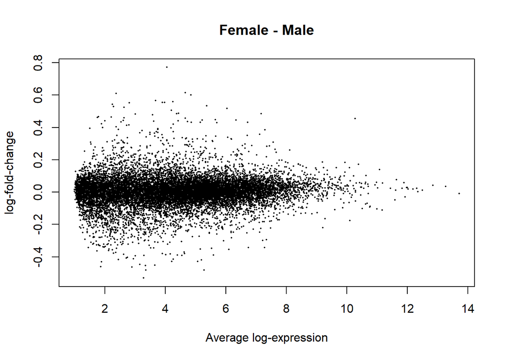

```r
plotMD(fit_log)
```

Não há genes diferencialmente expressos entre os sexos.

```r
#Outra variável (tipo de amostra)
subset_sample$SAMPLE_SITE = as.factor(subset_sample$SAMPLE_SITE)
levels(subset_sample$SAMPLE_SITE) = make.names(levels(subset_sample$SAMPLE_SITE))

y <- DGEList(counts = RNA_cpm, genes = row.names(RNA_cpm), group = subset_sample$SAMPLE_SITE)
```

```
## Setting first column of `counts` as gene annotation.
```

```r
design2 = model.matrix(~0+subset_sample$SAMPLE_SITE, data = y$samples)
colnames(design2) = levels(subset_sample$SAMPLE_SITE)
head(design2)
```

```
##                        Bone.Marrow.Aspirate Leukapheresis Peripheral.Blood
## aml_ohsu_2018_12.00023                    1             0                0
## aml_ohsu_2018_12.00051                    0             0                1
## aml_ohsu_2018_12.00066                    0             0                1
## aml_ohsu_2018_12.00150                    1             0                0
## aml_ohsu_2018_12.00211                    1             0                0
## aml_ohsu_2018_12.00258                    0             0                1
```

```r
contrast2 = makeContrasts( Bone_Leuk = Bone.Marrow.Aspirate - Leukapheresis,
                           Bone_Blood = Bone.Marrow.Aspirate - Peripheral.Blood,
                           Leuk_Blood = Leukapheresis - Peripheral.Blood, levels=design2)
keep <- filterByExpr(y, design2)
y <- y[keep, , keep.lib.sizes=FALSE]

v <- voom(y,design2)

fit2 <- lmFit(v, design2)

fit2 <- contrasts.fit(fit2, contrast2)

fit2 <- eBayes(fit2, trend = F, robust = F)

summa.fit2 <- decideTests(fit2)

summary(summa.fit2)
```

```
##        Bone_Leuk Bone_Blood Leuk_Blood
## Down           8          0          3
## NotSig     13712      13723      13704
## Up             3          0         16
```

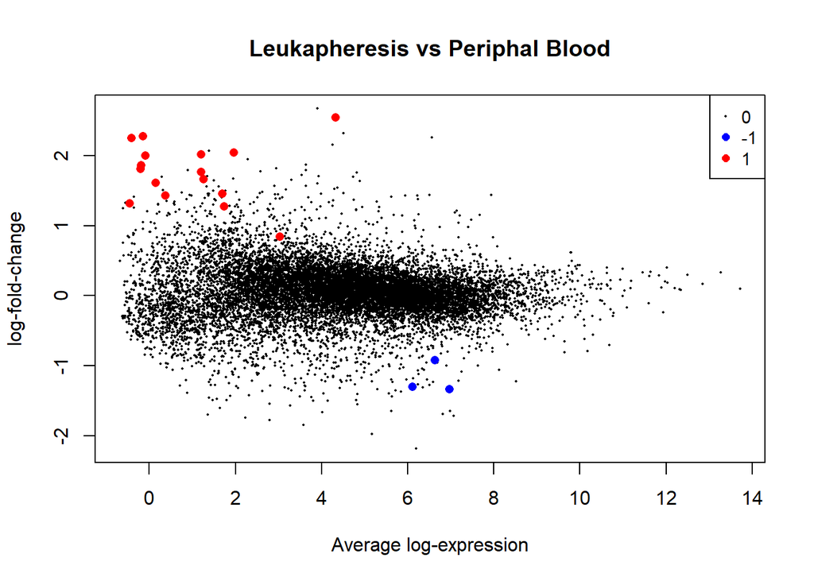

```r
plotMD(fit2,coef="Leuk_Blood",status=summa.fit2[,"Leuk_Blood"], values = c(-1, 1), hl.col=c("blue","red"), main = "Leukapheresis vs Periphal Blood")
```

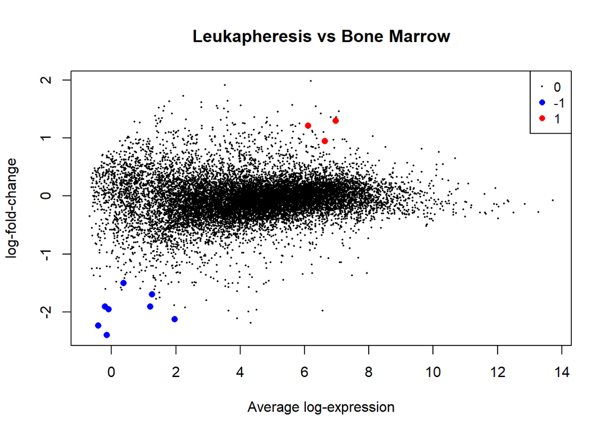

```r
plotMD(fit2,coef="Bone_Leuk",status=summa.fit2[,"Bone_Leuk"], values = c(-1, 1), hl.col=c("blue","red"), main = "Leukapheresis vs Bone Marrow")
```

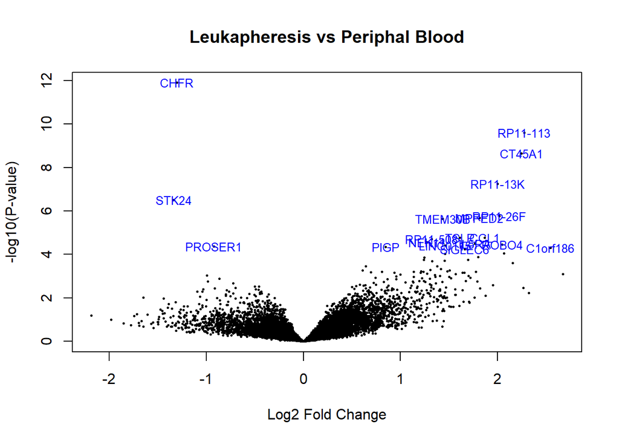

```r
volcanoplot(fit2,coef="Leuk_Blood",highlight=19,names=row.names(fit2), main ="Leukapheresis vs Periphal Blood")
```

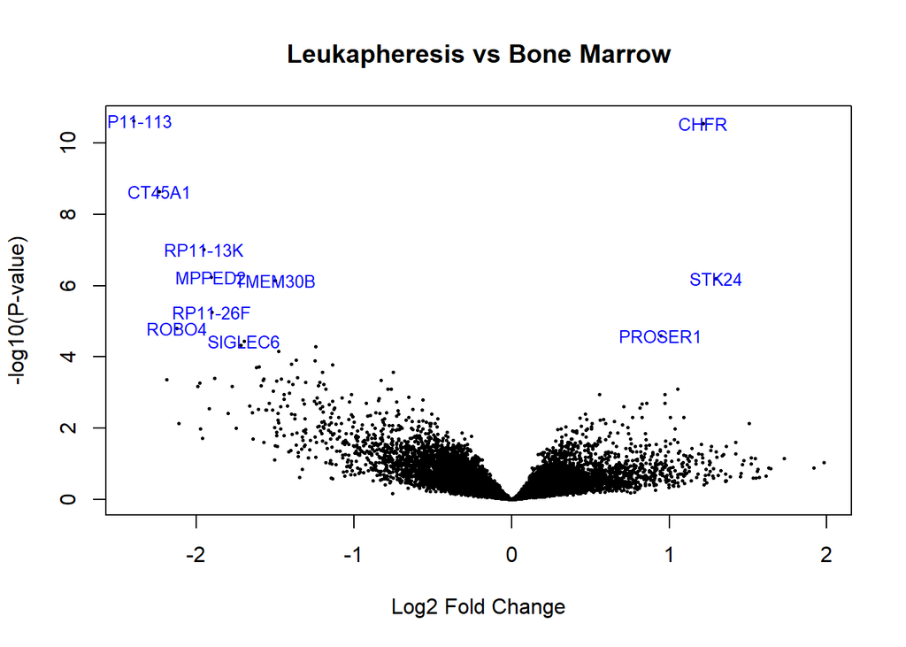

```r
volcanoplot(fit2,coef="Bone_Leuk",highlight=11,names=row.names(fit2), main ="Leukapheresis vs Bone Marrow")
```

[^1]: (Tyner *et al*., 2018)
[^2]: https://www.cbioportal.org/study/summary?id=aml_ohsu_2018
[^3]: https://github.com/lais-carvalho/Trabalho-pratico/tree/main/Dados